# DATA VISUALIZATION

# Outlier Detection

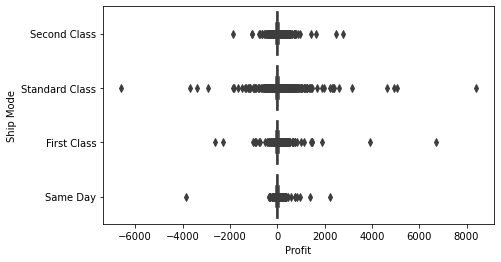

```python
plt.figure(figsize=(7,4))
sns.boxplot(x="Profit", y= "Ship Mode", data=df )
```

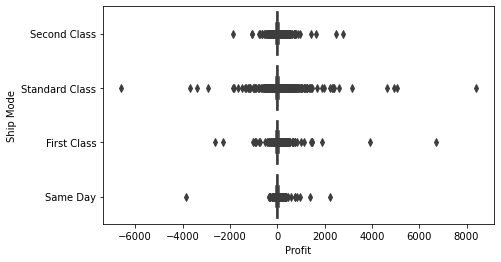

```python
plt.figure(figsize=(7,4))
sns.boxplot(x="Profit", y= "Ship Mode", data=df)
```

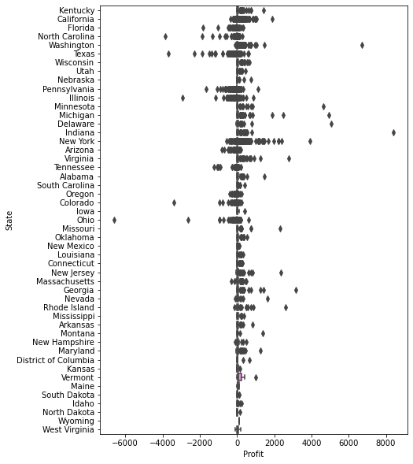

```python
plt.figure(figsize=(7,10))
sns.boxplot(x="Profit", y= "State", data=df)
```

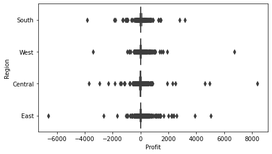

```python
plt.figure(figsize=(7,4))
sns.boxplot(x="Profit", y= "Region", data=df)
```

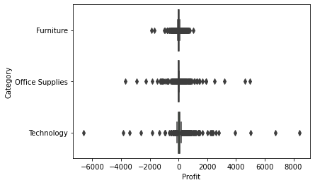

```python
sns.boxplot(x="Profit", y= "Category", data=df)
```

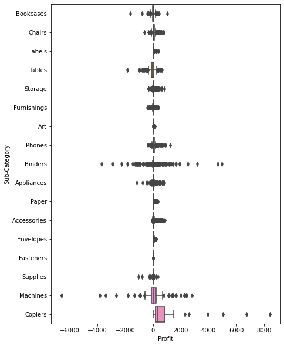

```python
plt.figure(figsize=(7,10))
sns.boxplot(x="Profit", y= "Sub-Category", data=df)
```

#### There are also outliers detected in each of the following , we need to delete them , to have further analysis

# Summary

#### 5) Among OFFICE SUPPLIES and TECHNOLOGY , we should give more preference to COPIERS , ACCESORIES and PHONES

#### 6) We should avoid using discounts as higher discounts lead to less profits to us , rather than this

#### we need to advertise our products in above prefered regions and states.

#### 7) We should rise our quantity of product in an appropraite manner , only in regions , states , categories

#### subcategories stated above , as increasing quantities on such aspect will definately flare up our

#### profits in definate manner .

#### 8) TO have a look for more appropraite profits , or for prediction of sales , we need to give some time to play

#### with outliers , either we can delete them or can rectify them .